# Exploratory Data Analysis on Customer Shopping Trends

## Project Description

This dataset provides details on customer shopping behaviour, including demographics, transaction records, payment methods, and purchasing patterns. The goal is to extract meaningful insights to help businesses understand the factors influencing customer purchasing decisions and recognize key trends in their behaviour.

```python
# Import libraries
import pandas as pd
import numpy as np
import matplotlib.pyplot as plt
import seaborn as sns
```

```python
# Import dataset
data = pd.read_csv('shopping_trends_updated.csv')
```

```python
# Display first 5 rows
data.head()
```

|  | Customer ID | Age | Gender | Item Purchased | Category | Purchase Amount (USD) | Location | Size | Color | Season | Review Rating | Subscription Status | Shipping Type | Discount Applied | Promo Code Used | Previous Purchases | Payment Method | Frequency of Purchases |
| --- | --- | --- | --- | --- | --- | --- | --- | --- | --- | --- | --- | --- | --- | --- | --- | --- | --- | --- |
| 0 | 1 | 55 | Male | Blouse | Clothing | 53 | Kentucky | L | Gray | Winter | 3.1 | Yes | Express | Yes | Yes | 14 | Venmo | Fortnightly |
| 1 | 2 | 19 | Male | Sweater | Clothing | 64 | Maine | L | Maroon | Winter | 3.1 | Yes | Express | Yes | Yes | 2 | Cash | Fortnightly |
| 2 | 3 | 50 | Male | Jeans | Clothing | 73 | Massachusetts | S | Maroon | Spring | 3.1 | Yes | Free Shipping | Yes | Yes | 23 | Credit Card | Weekly |
| 3 | 4 | 21 | Male | Sandals | Footwear | 90 | Rhode Island | M | Maroon | Spring | 3.5 | Yes | Next Day Air | Yes | Yes | 49 | PayPal | Weekly |
| 4 | 5 | 45 | Male | Blouse | Clothing | 49 | Oregon | M | Turquoise | Spring | 2.7 | Yes | Free Shipping | Yes | Yes | 31 | PayPal | Annually |

```python
# Display the number of rows and columns
data.shape
```

```
(3900, 18)
```

```python
# Display basic information about the data
data.info()
```

```
<class 'pandas.core.frame.DataFrame'>
RangeIndex: 3900 entries, 0 to 3899
Data columns (total 18 columns):
 #   Column                  Non-Null Count  Dtype
---  ------                  --------------  -----
 0   Customer ID             3900 non-null   int64
 1   Age                     3900 non-null   int64
 2   Gender                  3900 non-null   object
 3   Item Purchased          3900 non-null   object
 4   Category                3900 non-null   object
 5   Purchase Amount (USD)   3900 non-null   int64
 6   Location                3900 non-null   object
 7   Size                    3900 non-null   object
 8   Color                   3900 non-null   object
 9   Season                  3900 non-null   object
 10  Review Rating           3900 non-null   float64
 11  Subscription Status     3900 non-null   object
 12  Shipping Type           3900 non-null   object
 13  Discount Applied        3900 non-null   object
 14  Promo Code Used         3900 non-null   object
 15  Previous Purchases      3900 non-null   int64
 16  Payment Method          3900 non-null   object
 17  Frequency of Purchases  3900 non-null   object
dtypes: float64(1), int64(4), object(13)
memory usage: 548.6+ KB
```

```python
# Display descriptive statistics of the numeric columns
data.describe()
```

|  | Customer ID | Age | Purchase Amount (USD) | Review Rating | Previous Purchases |
| --- | --- | --- | --- | --- | --- |
| count | 3900.000000 | 3900.000000 | 3900.000000 | 3900.000000 | 3900.000000 |
| mean | 1950.500000 | 44.068462 | 59.764359 | 3.749949 | 25.351538 |
| std | 1125.977353 | 15.207589 | 23.685392 | 0.716223 | 14.447125 |
| min | 1.000000 | 18.000000 | 20.000000 | 2.500000 | 1.000000 |
| 25% | 975.750000 | 31.000000 | 39.000000 | 3.100000 | 13.000000 |
| 50% | 1950.500000 | 44.000000 | 60.000000 | 3.700000 | 25.000000 |
| 75% | 2925.250000 | 57.000000 | 81.000000 | 4.400000 | 38.000000 |
| max | 3900.000000 | 70.000000 | 100.000000 | 5.000000 | 50.000000 |

## Data Cleaning

```python
# Check for missing values
data.isna().sum()
```

```
Customer ID               0
Age                       0
Gender                    0
Item Purchased            0
Category                  0
Purchase Amount (USD)     0
Location                  0
Size                      0
Color                     0
Season                    0
Review Rating             0
Subscription Status       0
Shipping Type             0
Discount Applied          0
Promo Code Used           0
Previous Purchases        0
Payment Method            0
Frequency of Purchases    0
dtype: int64
```

No missing values in this dataset

```python
# Check for duplicate values
data.duplicated().sum()
```

```
0
```

No duplicated values in thie dataset

## Data Analysis & Visualization

### Demographics

What is the gender distribution of customers?

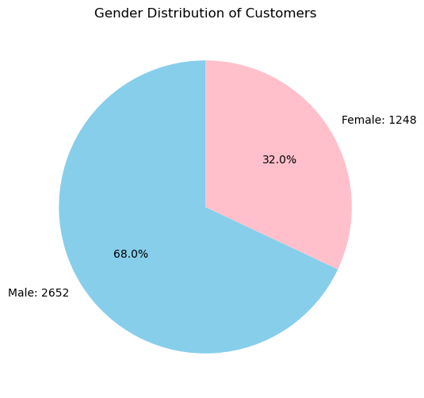

```python
# Calculate gender distribution
gender_counts = data['Gender'].value_counts()

# Create custom labels with counts
labels = [f"{gender}: {count}" for gender, count in zip(gender_counts.index, gender_counts.values)]

# Plot pie chart
plt.figure(figsize=(8, 6))
plt.pie(
    gender_counts,
    labels=labels,
    autopct='%1.1f%%',
    startangle=90,
    colors=['skyblue', 'pink']
)
plt.title('Gender Distribution of Customers')
plt.show()
```

What is the age distribution of customers?

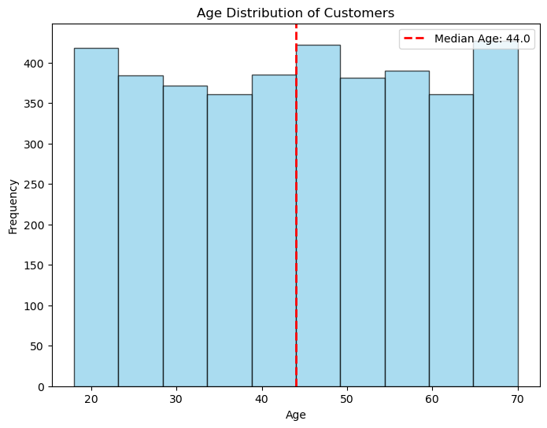

```python
# Calculate the median age
median_age = data['Age'].median()

# Plot the histogram
plt.figure(figsize=(8, 6))
plt.hist(data['Age'], bins=10, edgecolor='black', alpha=0.7, color='skyblue')

# Add a red line for the median age
plt.axvline(median_age, color='red', linestyle='dashed', linewidth=2, label=f'Median Age: {median_age}')

# Add labels, title, and legend
plt.title('Age Distribution of Customers')
plt.xlabel('Age')
plt.ylabel('Frequency')
plt.legend()

# Show the plot
plt.show()
```

How does purchase amount differ across various age groups?

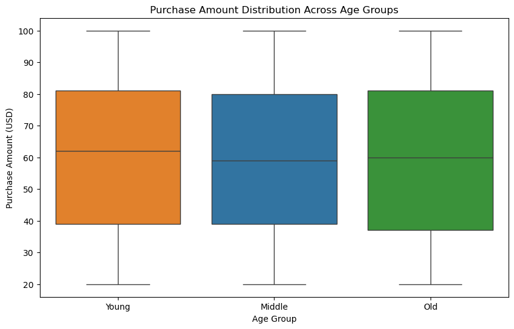

```python
# Function to create age groups
def age_group(age):
    if age <= 30:
        return 'Young'
    elif 31 <= age <= 64:
        return 'Middle'
    else:
        return 'Old'

# Add Age Group column
data['Age Group'] = data['Age'].apply(age_group)

# Create a box plot to compare purchase amounts across age groups in specified order
plt.figure(figsize=(10, 6))
sns.boxplot(
    data=data,
    x='Age Group',
    y='Purchase Amount (USD)',
    order=['Young', 'Middle', 'Old'],  # Specify the order
    hue='Age Group'
)

# Add titles and labels
plt.title('Purchase Amount Distribution Across Age Groups')
plt.xlabel('Age Group')
plt.ylabel('Purchase Amount (USD)')
plt.show()
```

How is the customer population distributed across different age groups?

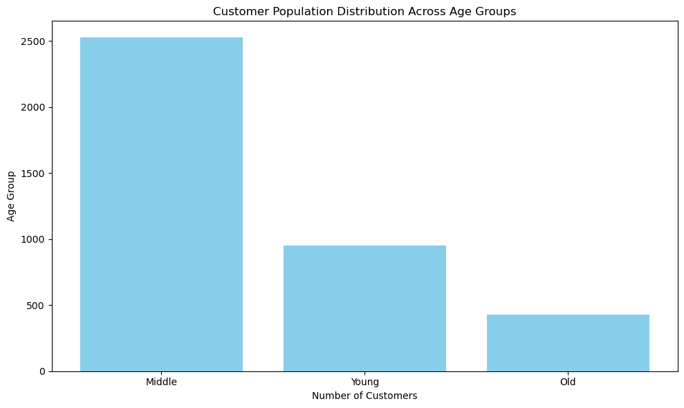

```python
# Count customers in each age group
age_group_counts = data['Age Group'].value_counts()

# Create a horizontal bar chart
plt.figure(figsize=(10, 6))
bars = plt.bar(age_group_counts.index, age_group_counts.values, color='skyblue')

# Add titles and labels
plt.title('Customer Population Distribution Across Age Groups')
plt.xlabel('Number of Customers')
plt.ylabel('Age Group')
plt.tight_layout()

# Show the plot
plt.show()
```

### Geographics

What is the geographic distribution of customers?

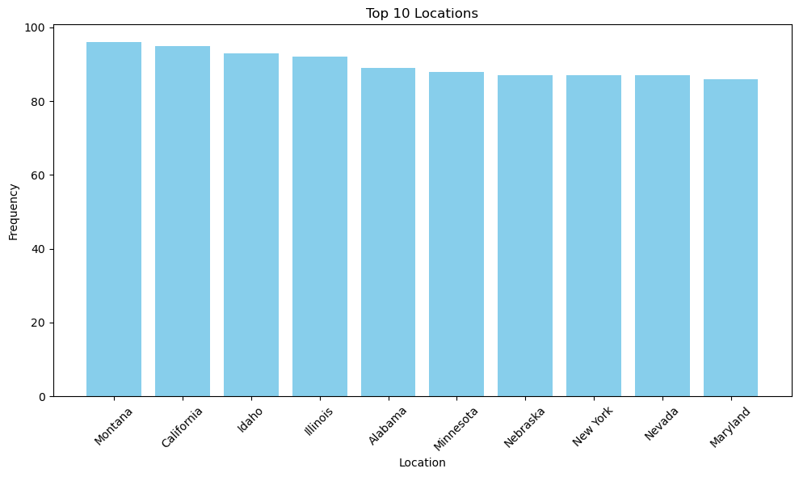

```python
# Count the top 10 locations
top_locations = data['Location'].value_counts().sort_values(ascending=False).head(10)

# Create a vertical bar chart
plt.figure(figsize=(10, 6))
bars = plt.bar(top_locations.index, top_locations.values, color='skyblue')

# Add titles and labels
plt.title('Top 10 Locations')
plt.xlabel('Location')
plt.ylabel('Frequency')
plt.xticks(rotation=45)
plt.tight_layout()

# Show the plot
plt.show()
```

Which locations have the highest total purchase amounts?

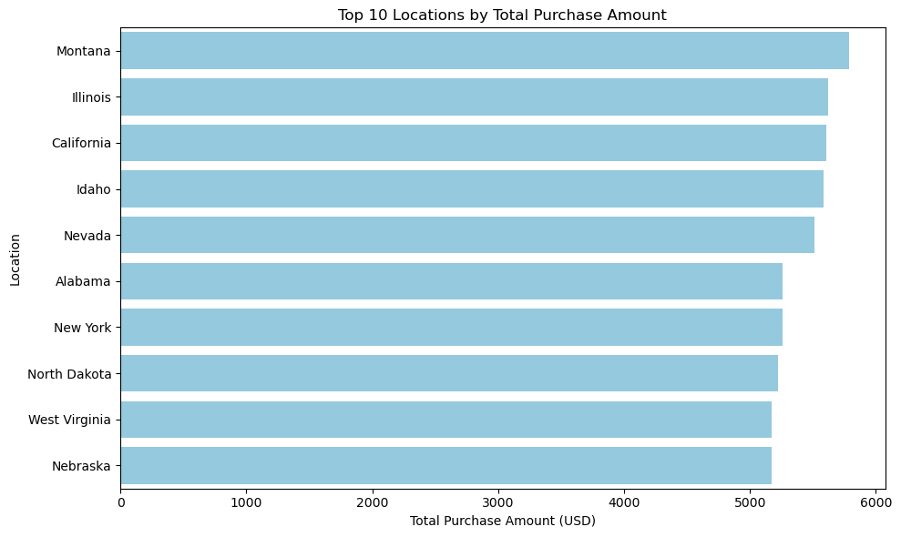

```python
# Group by Location and sum the Purchase Amounts
location_purchase = data.groupby('Location')['Purchase Amount (USD)'].sum().reset_index()

# Get the top 10 locations
top_10_locations = location_purchase.sort_values(by='Purchase Amount (USD)', ascending=False).head(10)

# Create a horizontal bar chart with descending order (top-to-bottom)
plt.figure(figsize=(10, 6))
bar_plot = sns.barplot(x='Purchase Amount (USD)',
                       y='Location',
                       data=top_10_locations,
                       color='skyblue')

# Add titles and labels
plt.title('Top 10 Locations by Total Purchase Amount')
plt.xlabel('Total Purchase Amount (USD)')
plt.ylabel('Location')
plt.tight_layout()

# Show the plot
plt.show()
```

### Purchasing Patterns

What are the most frequently purchased items?

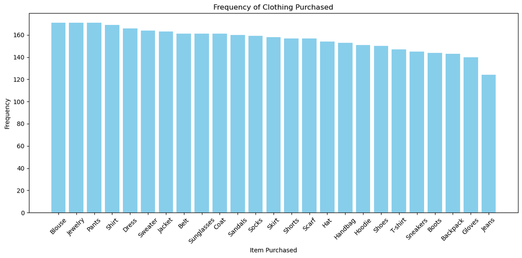

```python
# Count the frequency of each item
item_counts = data['Item Purchased'].value_counts()

# Create a vertical bar chart
plt.figure(figsize=(12, 6))
plt.bar(item_counts.index, item_counts.values, color='skyblue')

# Add titles and labels
plt.title('Frequency of Clothing Purchased')
plt.xlabel('Item Purchased')
plt.ylabel('Frequency')
plt.xticks(rotation=45)
plt.tight_layout()

# Show the plot
plt.show()
```

How do clothing preferences differ between genders?

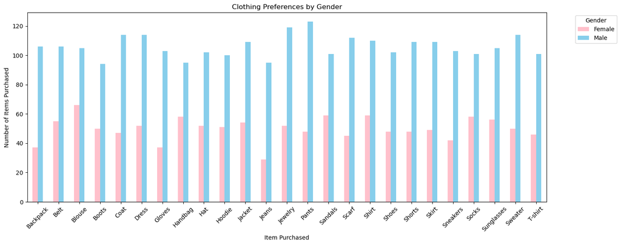

```python
# Group by Item Purchased and Gender, then count occurrences
gender_item_counts = data.groupby('Item Purchased')['Gender'].value_counts()

# Unstack the grouped data to reshape it for plotting
gender_item_counts = gender_item_counts.unstack()

# Plot the bar chart
gender_item_counts.plot(kind='bar', figsize=(15, 6), color=['pink', 'skyblue'])

# Add titles and labels
plt.title('Clothing Preferences by Gender')
plt.xlabel('Item Purchased')
plt.ylabel('Number of Items Purchased')
plt.xticks(rotation=45)
plt.legend(title='Gender', bbox_to_anchor=(1.05, 1), loc='upper left')
plt.tight_layout()

# Show the plot
plt.show()
```

Which clothing sizes are purchased most often?

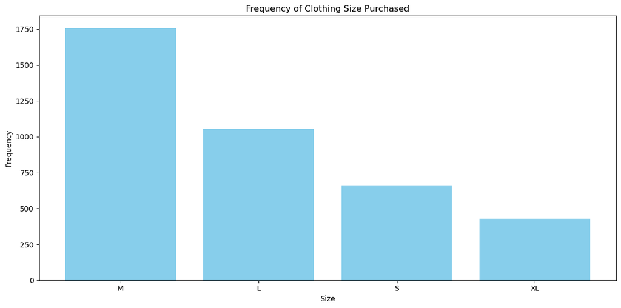

```python
# Count each clothing size
clothing_size_counts = data['Size'].value_counts()

# Create a vertical bar chart
plt.figure(figsize=(12, 6))
plt.bar(clothing_size_counts.index, clothing_size_counts.values, color='skyblue')

# Add titles and labels
plt.title('Frequency of Clothing Size Purchased')
plt.xlabel('Size')
plt.ylabel('Frequency')
plt.xticks(rotation=0)
plt.tight_layout()

# Show the plot
plt.show()
```

During which seasons do purchases peak?

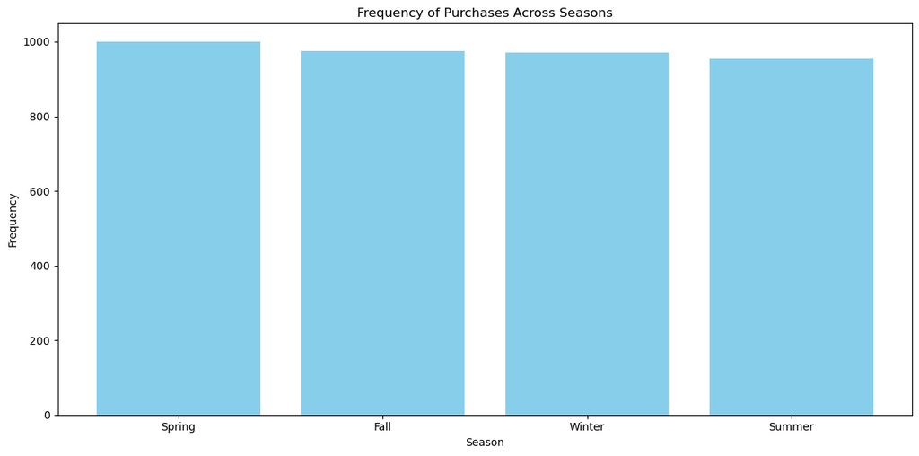

```python
# Count season's clothing
season_counts = data['Season'].value_counts()

# Create a vertical bar chart
plt.figure(figsize=(12, 6))
plt.bar(season_counts.index, season_counts.values, color='skyblue')

# Add titles and labels
plt.title('Frequency of Purchases Across Seasons')
plt.xlabel('Season')
plt.ylabel('Frequency')
plt.xticks(rotation=0)
plt.tight_layout()

# Show the plot
plt.show()
```

What is the total purchase amount for each category in different seasons?

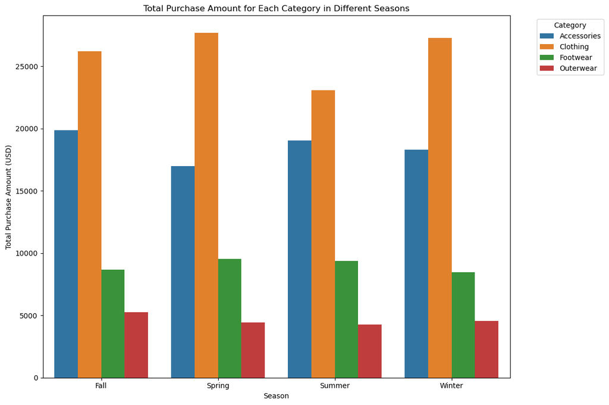

```python
# Group by Season and Category, then sum Purchase Amount
gender_item_counts = data.groupby(['Season', 'Category'])['Purchase Amount (USD)'].sum().reset_index()

# Create a bar chart
plt.figure(figsize=(12, 8))
sns.barplot(
    data=gender_item_counts,
    x='Season',
    y='Purchase Amount (USD)',
    hue='Category'
)

# Add titles and labels
plt.title('Total Purchase Amount for Each Category in Different Seasons')
plt.xlabel('Season')
plt.ylabel('Total Purchase Amount (USD)')
plt.legend(title='Category', bbox_to_anchor=(1.05, 1), loc='upper left')
plt.tight_layout()

# Show the plot
plt.show()
```

How is the purchase amount distributed across seasons?

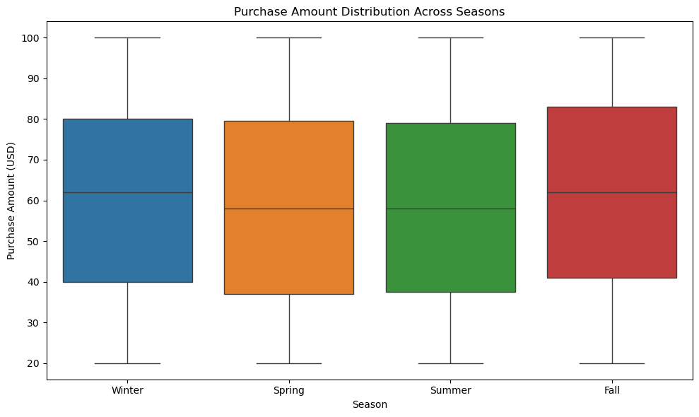

```python
# Create a box plot to analyze the purchase amount distribution across seasons
plt.figure(figsize=(10, 6))
sns.boxplot(data=data, x='Season', y='Purchase Amount (USD)', hue='Season')

# Add titles and labels
plt.title('Purchase Amount Distribution Across Seasons')
plt.xlabel('Season')
plt.ylabel('Purchase Amount (USD)')
plt.tight_layout()

# Show the plot
plt.show()
```

### Transaction Records

Which shipping method is the most commonly used?

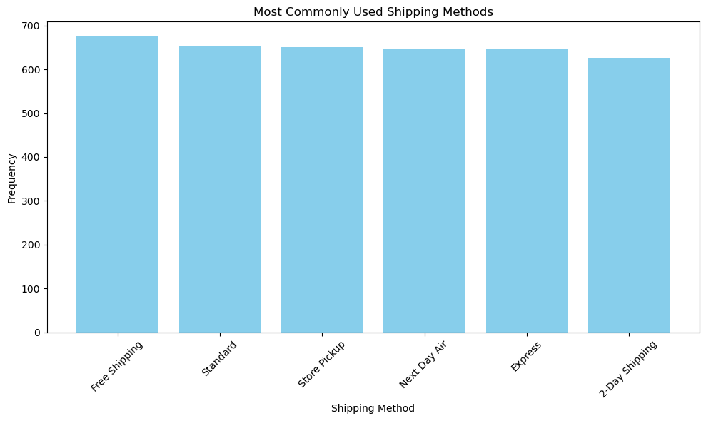

```python
# Count the occurrences of each shipping type
shipping_counts = data['Shipping Type'].value_counts()

# Create a bar chart
plt.figure(figsize=(10, 6))
plt.bar(shipping_counts.index, shipping_counts.values, color='skyblue')

# Add titles and labels
plt.title('Most Commonly Used Shipping Methods')
plt.xlabel('Shipping Method')
plt.ylabel('Frequency')
plt.xticks(rotation=45)

plt.tight_layout()
plt.show()
```

How are review ratings distributed?

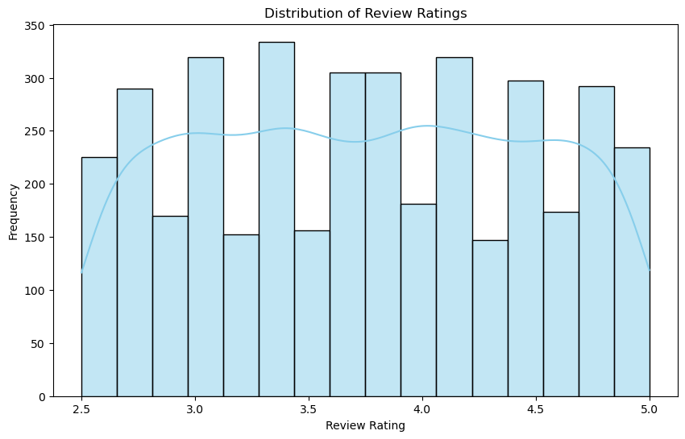

```python
# Create a histogram to visualize the distribution of review ratings
plt.figure(figsize=(10, 6))
sns.histplot(data['Review Rating'], color = 'skyblue', kde=True)

# Add title and labels
plt.title('Distribution of Review Ratings')
plt.xlabel('Review Rating')
plt.ylabel('Frequency')

# Show the plot
plt.show()
```

What is the relationship between subscription status and purchase frequency?

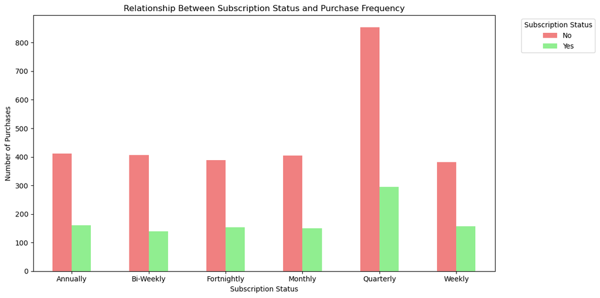

```python
# Replace 'Every 3 Months' with 'Quarterly'
data['Frequency of Purchases'] = data['Frequency of Purchases'].replace('Every 3 Months', 'Quarterly')

# Group by Subscription Status and Frequency of Purchases
subscription_purchase_counts = data.groupby('Frequency of Purchases')['Subscription Status'].value_counts().unstack()

# Plot the bar chart
subscription_purchase_counts.plot(kind='bar', figsize=(12, 6), color=['lightcoral', 'lightgreen'])

# Add titles and labels
plt.title('Relationship Between Subscription Status and Purchase Frequency')
plt.xlabel('Subscription Status')
plt.ylabel('Number of Purchases')
plt.legend(title='Subscription Status', bbox_to_anchor=(1.05, 1), loc='upper left')
plt.xticks(rotation=0)
plt.tight_layout()

# Show the plot
plt.show()
```

How does subscription status differ between genders?

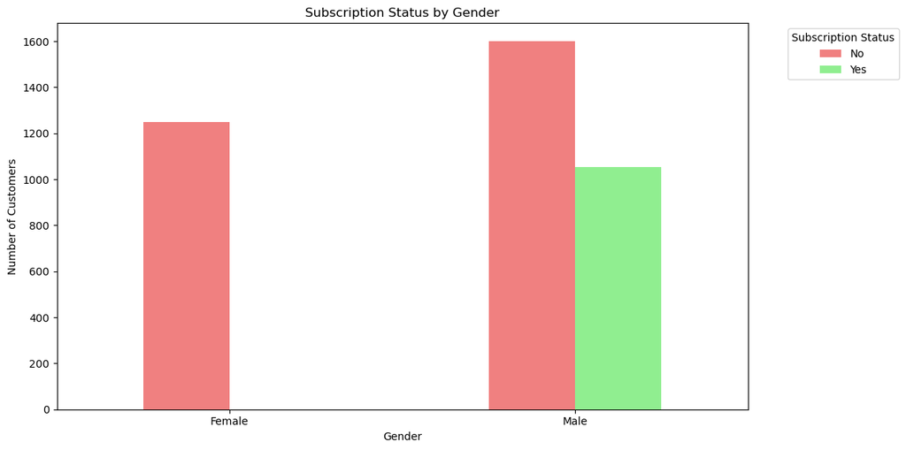

```python
# Group by Gender and Subscription Status, then count occurrences
gender_subscription_counts = data.groupby('Gender')['Subscription Status'].value_counts().unstack()

# Plot the bar chart
gender_subscription_counts.plot(kind='bar', figsize=(12, 6), color=['lightcoral', 'lightgreen'])

# Add titles and labels
plt.title('Subscription Status by Gender')
plt.xlabel('Gender')
plt.ylabel('Number of Customers')
plt.legend(title='Subscription Status', bbox_to_anchor=(1.05, 1), loc='upper left')
plt.xticks(rotation=0)
plt.tight_layout()

# Show the plot
plt.show()
```

How does applying a discount affect customers’ total purchase amounts?

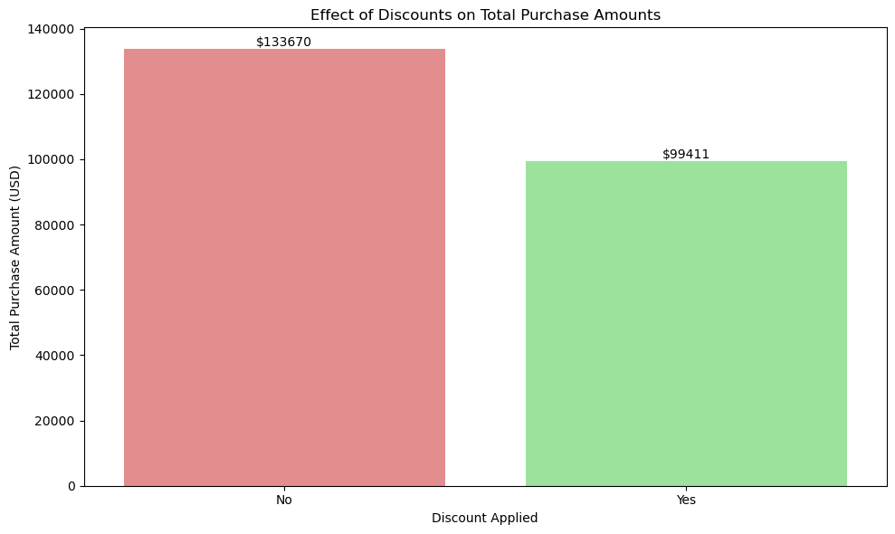

```python
# Calculate total purchase amount grouped by Discount Applied
total_purchase = data.groupby('Discount Applied')['Purchase Amount (USD)'].sum().reset_index()

# Create a bar chart to compare total purchase amounts
plt.figure(figsize=(10, 6))
sns.barplot(
    data=total_purchase,
    x='Discount Applied',
    y='Purchase Amount (USD)',
    hue='Discount Applied',  # Assigning hue
    palette={'Yes': 'lightgreen', 'No': 'lightcoral'},  # Mapping colors
    dodge=False  # Ensures bars are not separated
)

# Add labels above each bar
for index, row in total_purchase.iterrows():
    plt.text(index, row['Purchase Amount (USD)'], f"${row['Purchase Amount (USD)']:.0f}", ha='center', va='bottom')

# Add titles and labels
plt.title("Effect of Discounts on Total Purchase Amounts")
plt.xlabel("Discount Applied")
plt.ylabel("Total Purchase Amount (USD)")
plt.legend([], [], frameon=False)  # Removes legend
plt.tight_layout()

# Show the plot
plt.show()
```

How does using promo codes impact the total purchase amounts?

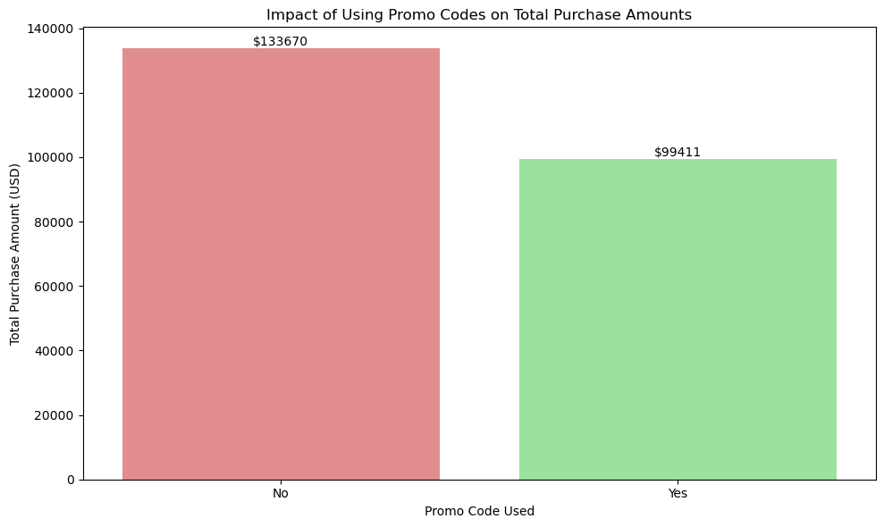

```python
# Calculate total purchase amount grouped by Promo Code Used
total_purchase = data.groupby('Promo Code Used')['Purchase Amount (USD)'].sum().reset_index()

# Create a bar chart to compare total purchase amounts
plt.figure(figsize=(10, 6))
sns.barplot(
    data=total_purchase,
    x='Promo Code Used',
    y='Purchase Amount (USD)',
    hue='Promo Code Used',  # Assigning hue
    palette={'Yes': 'lightgreen', 'No': 'lightcoral'},  # Mapping colors
    dodge=False  # Ensures bars are not separated
)

# Add labels above each bar
for index, row in total_purchase.iterrows():
    plt.text(index, row['Purchase Amount (USD)'], f"${row['Purchase Amount (USD)']:.0f}", ha='center', va='bottom')

# Add titles and labels
plt.title("Impact of Using Promo Codes on Total Purchase Amounts")
plt.xlabel("Promo Code Used")
plt.ylabel("Total Purchase Amount (USD)")
plt.legend([], [], frameon=False)  # Removes legend
plt.tight_layout()

# Show the plot
plt.show()
```

```python
# Filter data for rows where both 'Discount Applied' and 'Promo Code Used' are 'Yes'
yes_discount_promo = data[(data['Discount Applied'] == 'Yes') & (data['Promo Code Used'] == 'Yes')]

# Count the number of such rows
count_yes_discount_promo = yes_discount_promo.shape[0]
count_yes_discount_promo
```

```
1677
```

```python
# Filter data for rows where both 'Discount Applied' and 'Promo Code Used' are 'No'
no_discount_promo = data[(data['Discount Applied'] == 'No') & (data['Promo Code Used'] == 'No')]

# Count the number of such rows
count_no_discount_promo = no_discount_promo.shape[0]
count_no_discount_promo
```

```
2223
```

When discounts and promo codes are given together, customers probably could not use one without the other. This might be part of a planned marketing strategy.

### Payment Method

Which payment method is used most frequently?

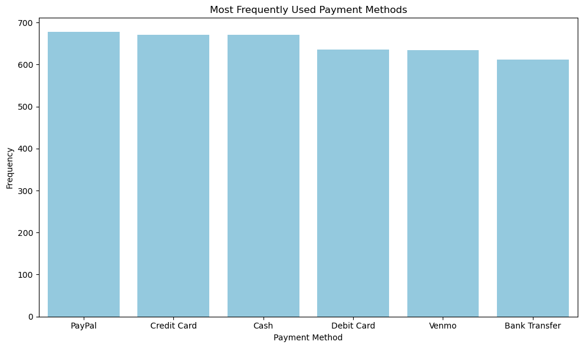

```python
# Count the occurrences of each payment method
payment_method_counts = data['Payment Method'].value_counts().reset_index()
payment_method_counts.columns = ['Payment Method', 'Frequency']

# Create a bar chart to visualize the most frequently used payment methods
plt.figure(figsize=(10, 6))
sns.barplot(data=payment_method_counts, x='Payment Method', y='Frequency', color='skyblue')

# Add titles and labels
plt.title("Most Frequently Used Payment Methods")
plt.xlabel("Payment Method")
plt.ylabel("Frequency")
plt.xticks(rotation=0)
plt.tight_layout()

# Show the plot
plt.show()
```

How does the preferred payment method differ across age groups?

[figure not shown]

```python
# Count the occurrences of each payment method by age group
age_payment_counts = data.groupby('Payment Method')['Age Group'].value_counts().unstack()

# Create a grouped bar chart to compare payment methods across age groups
age_payment_counts.plot(kind='bar', figsize=(12, 6))

# Add titles and labels
plt.title("Preferred Payment Methods Across Age Groups")
plt.xlabel("Age Group")
plt.ylabel("Frequency")
plt.xticks(rotation=0)
plt.legend(title="Age Group", bbox_to_anchor=(1.05, 1), loc='upper left')
plt.tight_layout()

# Show the plot
plt.show()
```

How does the choice of payment method vary by location?

```python
# Count the occurrences of each payment method by location
location_payment_counts = data.groupby('Location')['Payment Method'].value_counts().unstack()

# Find the maximum payment method for each location
max_payment_methods = location_payment_counts.idxmax(axis=1)

max_payment_methods
```

```
Location
Alabama              Debit Card
Alaska              Credit Card
Arizona              Debit Card
Arkansas                   Cash
California               PayPal
Colorado          Bank Transfer
Connecticut                Cash
Delaware                  Venmo
Florida             Credit Card
Georgia             Credit Card
Hawaii            Bank Transfer
Idaho                    PayPal
Illinois                  Venmo
Indiana           Bank Transfer
Iowa                       Cash
Kansas              Credit Card
Kentucky                 PayPal
Louisiana           Credit Card
Maine                     Venmo
Maryland            Credit Card
Massachusetts              Cash
Michigan                 PayPal
Minnesota                PayPal
Mississippi         Credit Card
Missouri          Bank Transfer
Montana           Bank Transfer
Nebraska                   Cash
Nevada              Credit Card
New Hampshire              Cash
New Jersey                Venmo
New Mexico               PayPal
New York          Bank Transfer
North Carolina       Debit Card
North Dakota               Cash
Ohio                     PayPal
Oklahoma          Bank Transfer
Oregon                   PayPal
Pennsylvania               Cash
Rhode Island             PayPal
South Carolina             Cash
South Dakota               Cash
Tennessee                PayPal
Texas                Debit Card
Utah                     PayPal
Vermont                  PayPal
Virginia            Credit Card
Washington           Debit Card
West Virginia       Credit Card
Wisconsin         Bank Transfer
Wyoming              Debit Card
dtype: object
```

## Insights & Conclusion

- Male customers comprise 68% of the customer base, while female customers account for 32%. This indicates that the current clothing offerings may resonate more strongly with male customers. This imbalance presents an opportunity to enhance the range of women’s clothing and refine marketing strategies to better engage and attract female customers, thereby diversifying the customer base.
- The customer age range spans from 18 to 70, with a relatively even distribution across all ages. However, the middle-aged group (31 to 64 years old) represents a significant majority, accounting for 64.71% of the customer base.
- Montana, California, Illinois, and Idaho contribute the highest sales and customer numbers. This highlights a potential opportunity to optimize marketing strategies in these regions to further engage and attract the target audience
- Blouses, jewelry, and pants are the top three most popular items among customers. Notably, jewelry and pants are purchased by male customers, while blouses are favored by female customers. This insight suggests that expanding the designs of these high-demand products could drive increased sales.
- Medium-sized products are the most frequently purchased by customers. This suggests that a significant portion of inventory should be allocated to Medium sizes to align with customer demand and minimize excess stock in other sizes.
- The highest sales occur during the spring season, with clothing and accessories being the most frequently purchased items. To meet this seasonal demand, increasing the production of these high-demand products can help ensure sufficient stock availability during the peak spring period.
- The free shipping method is the most popular choice among customers. This presents an opportunity to implement a strategic free shipping offer, such as providing it for orders exceeding a minimum purchase amount, to encourage higher spending and boost revenue.
- Review ratings range from 2.5 to 5.0, with 3.4 being the most frequently given rating, followed by 4.0. To enhance the average rating, efforts could focus on improving product quality and delivery services.
- There are more male customers than female customers in both subscriber and non-subscriber categories. This suggests an opportunity to implement targeted strategies aimed at increasing overall subscriptions, with a particular focus on attracting more female subscribers.
- PayPal is the most preferred payment method among middle-aged customers, credit cards are favored by older customers, and cash is predominantly used by younger customers. To optimize transaction efficiency and meet customer expectations, it is essential to prioritize the maintenance and reliability of PayPal and credit card payment systems. Additionally, ensuring sufficient cash availability is critical to accommodate the preferences of younger customers. These measures will help prevent transaction failures and enhance the overall customer experience.